# Exercicio 1: limpeza de dados

# 2. Checando dados da espécie

Uma vez que temos os dados brutos, um passo importante é checar a consistência do nome específico.

Primeiro vamos checar quantos nomes científicos foram importados. Note que a função unique() retorna todos os nomes únicos para a coluna indicada:

```r
sort(unique(occs$data$scientificName))
```

```
## [1] "Euglossa annectans Dressler, 1982"
```

**Neste caso, temos apenas um nome, então estamos bem para prosseguir.**

Também podemos checar outros campos do banco de dados:

```r
sort(unique(occs$data$species))
```

```
## [1] "Euglossa annectans"
```

```r
sort(unique(occs$data$speciesKey))
```

```
## [1] 9101860
```

Veja que para os dois comandos, foram retornados dados únicos. Assim, podemos seguir sem precisar consolidar esses dados.

**Embora simples esse passos são fundamentais e pode interferir em toda modelagem. Gaste o tempo que for necessário aqui para confirmar se a espécie está corretamente anotada.**

**Dica importante: caso note que é necessário alterar algo em relação ao nome da espécie, nunca faça isso no objeto original, crie um objeto novo, algo como:**

`dados<-occs$data`. Em seguida edite faça as alterações sobre o objeto `dados`.

# 3. Checando coordenadas

Uma vez que definimos que não há problemas com a espécie, podemos seguir adiante.

Vamos primeiro plotar a latitude e longitude para observar seu padrão:

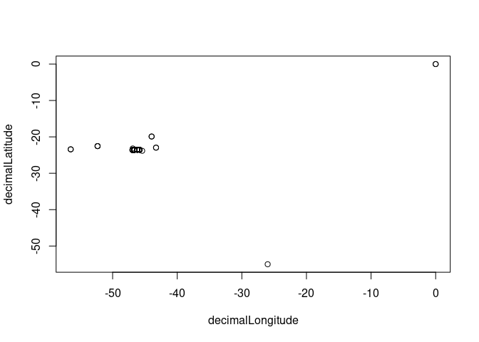

```r
plot(decimalLatitude ~ decimalLongitude, data = occs$data)
```

```r
#map(, , , add = TRUE)
```

*Plot lat ~ long*

### Primero checaremos a unicidade dos dados…

Para esse exercício não precisaremos de redundância, portanto trabalharemos apenas com registros únicos, que não se repetem tampouco em Lat ou Long.

Aplicaremos a função “levels” que retorna os níveis (elementos únicos) dos fatores (variável categórica). A função “as.factor” transforma em fator (categorias) o parâmetro que é passado, neste caso, os dados da coluna decimalLatitude.

```r
levels(as.factor(occs$data$decimalLatitude))
```

```
##  [1] "-55"        "-23.8311"   "-23.6039"   "-23.5475"   "-23.5322"
##  [6] "-23.5228"   "-23.423056" "-23.1864"   "-22.95831"  "-22.5425"
## [11] "-19.90174"  "0"
```

Fazemos o mesmo para longitude

```r
levels(as.factor(occs$data$decimalLongitude))
```

```
##  [1] "-56.487472" "-52.327778" "-46.9192"   "-46.8842"   "-46.6361"
##  [6] "-46.1883"   "-45.8464"   "-45.4264"   "-43.9642"   "-43.27721"
## [11] "-26"        "0"
```

**Note ainda que, embora temos checado os dados, ainda não os alteramos de forma direta, faremos isso a partir de agora**

### Corrigindo os dados

Primeiramente, removeremos os valores tidos como não disponíveis, ou NA.

```r
occs.coord <- occs$data[!is.na(occs$data$decimalLatitude)
                   & !is.na(occs$data$decimalLongitude),]

head(occs.coord)
```

```
## # A tibble: 6 x 103
##   key   scientificName decimalLatitude decimalLongitude issues datasetKey
##   <chr> <chr>                    <dbl>            <dbl> <chr>  <chr>
## 1 3290… Euglossa anne…           -23.5            -45.8 gass8… 86aba78e-…
## 2 3290… Euglossa anne…           -23.8            -45.4 gass8… 86aba78e-…
## 3 3290… Euglossa anne…           -23.5            -46.2 gass8… 86aba78e-…
## 4 3290… Euglossa anne…           -23.5            -45.8 gass8… 86aba78e-…
## 5 3290… Euglossa anne…           -23.5            -45.8 gass8… 86aba78e-…
## 6 3290… Euglossa anne…           -23.5            -46.2 gass8… 86aba78e-…
## # … with 97 more variables: publishingOrgKey <chr>, installationKey <chr>,
## #   publishingCountry <chr>, protocol <chr>, lastCrawled <chr>,
## #   lastParsed <chr>, crawlId <int>, hostingOrganizationKey <chr>,
## #   basisOfRecord <chr>, occurrenceStatus <chr>, sex <chr>, taxonKey <int>,
## #   kingdomKey <int>, phylumKey <int>, classKey <int>, orderKey <int>,
## #   familyKey <int>, genusKey <int>, speciesKey <int>, acceptedTaxonKey <int>,
## #   acceptedScientificName <chr>, kingdom <chr>, phylum <chr>, order <chr>,
## #   family <chr>, genus <chr>, species <chr>, genericName <chr>,
## #   specificEpithet <chr>, taxonRank <chr>, taxonomicStatus <chr>,
## #   continent <chr>, stateProvince <chr>, year <int>, month <int>, day <int>,
## #   eventDate <chr>, modified <chr>, lastInterpreted <chr>, license <chr>,
## #   identifiers <chr>, facts <chr>, relations <chr>, isInCluster <lgl>,
## #   geodeticDatum <chr>, class <chr>, countryCode <chr>, recordedByIDs <chr>,
## #   identifiedByIDs <chr>, country <chr>, rightsHolder <chr>, identifier <chr>,
## #   locality <chr>, municipality <chr>, datasetName <chr>, gbifID <chr>,
## #   language <chr>, collectionCode <chr>, occurrenceID <chr>, type <chr>,
## #   catalogNumber <chr>, recordedBy <chr>, institutionCode <chr>,
## #   ownerInstitutionCode <chr>, name <chr>, gadm <chr>, lifeStage <chr>,
## #   http...unknown.org.rights <chr>, http...unknown.org.language <chr>,
## #   http...unknown.org.rightsHolder <chr>, fieldNumber <chr>,
## #   occurrenceRemarks <chr>, identifiedBy <chr>, higherGeography <chr>,
## #   institutionID <chr>, county <chr>, preparations <chr>, rights <chr>,
## #   coordinateUncertaintyInMeters <dbl>, institutionKey <chr>,
## #   collectionKey <chr>, georeferencedBy <chr>, georeferenceProtocol <chr>,
## #   accessRights <chr>, dateIdentified <chr>, typeStatus <chr>,
## #   X.99d66b6c.9087.452f.a9d4.f15f2c2d0e7e. <chr>, individualCount <int>,
## #   verbatimEventDate <chr>, endDayOfYear <chr>, startDayOfYear <chr>,
## #   higherClassification <chr>, verbatimLocality <chr>, waterBody <chr>,
## #   taxonID <chr>, locationID <chr>, samplingProtocol <chr>
```

```r
print(paste("com NA:", nrow(occs$data))) #com NA
```

```
## [1] "com NA: 126"
```

```r
print(paste("sem NA:", nrow(occs.coord))) #sem NA
```

```
## [1] "sem NA: 107"
```

Após remover os “NA” podemos salvar os dados em um novo objeto (chamado aqui “gbif”) que será um dataframe com três colunas: *species*, *decimalLongitude* e *decimalLatitude*. Note que a ordem desses campos é importate. Devem corresponder à *nome da espécie*, *valor para o eixo X* e *valor para o eixo Y* + PS: *alterei a ordem dos campos em relação ao vídeo, agora estão como deveriam estar*

**Note que aqui não utilizaremos os dados adicionais da tabela, por isso nos damos ao luxo de utilizar apenas as três colunas.**

```r
#Criando uma tabela nova apenas com spp, long e lat.
gbif<-data.frame("species" = occs.coord$species,
                 "decimalLongitude" = occs.coord$decimalLongitude,
                  "decimalLatitude" = occs.coord$decimalLatitude
                 )
head(gbif) #primeiras 10 linhas
```

```
##              species decimalLongitude decimalLatitude
## 1 Euglossa annectans         -45.8464        -23.5322
## 2 Euglossa annectans         -45.4264        -23.8311
## 3 Euglossa annectans         -46.1883        -23.5228
## 4 Euglossa annectans         -45.8464        -23.5322
## 5 Euglossa annectans         -45.8464        -23.5322
## 6 Euglossa annectans         -46.1883        -23.5228
```

```r
tail(gbif) #últimas 10 linhas
```

```
##                species decimalLongitude decimalLatitude
## 102 Euglossa annectans        -56.48747       -23.42306
## 103 Euglossa annectans        -52.32778       -22.54250
## 104 Euglossa annectans        -26.00000       -55.00000
## 105 Euglossa annectans        -52.32778       -22.54250
## 106 Euglossa annectans        -52.32778       -22.54250
## 107 Euglossa annectans          0.00000         0.00000
```

Há formas alternativas de visualizar os dados:

```r
#vizualizando os dados no Rstudio
View(gbif)
```

Podemos contar os registros:

```r
#contando quantas linhas há na tabela gbif
nrow(gbif)
```

```
## [1] 107
```

E quantos restaram após remover os dados não disponíveis:

```r
#Numero de linhas no dado original
nrow(occs$data)
```

```
## [1] 126
```

```r
#Original menos o modificado
nrow(occs$data)-nrow(gbif)
```

```
## [1] 19
```

Podemos novamente visualizar as latitudes.

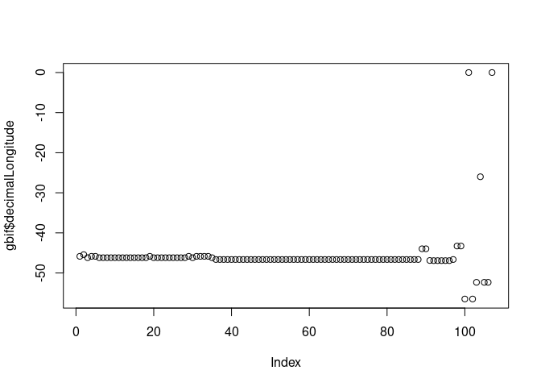

```r
#Visual checking
plot(gbif$decimalLongitude)
```

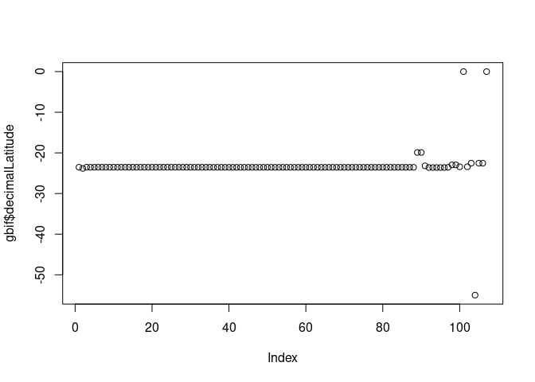

```r
plot(gbif$decimalLatitude)
```

[Plotes de Latitude e longitude. Note que nestes plotes há uma diferença entre plotar Latitude contra longitude. Aqui podemos ver a repetição dos valores (em Y) ao longo dos registros (em X).]

#### Checando os dados no mapa:

As próximas linhas de código vão importar os dados de vetor do maptools de um conjunto chamado wrld_simpl que possue as fronteiras dos países do mundo.

```r
#data from maptools
data("wrld_simpl")
```

As próximas linhas efetivamente plotam o mapa.

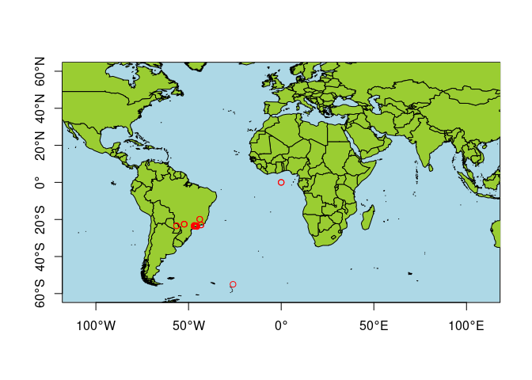

```r
#plotando o mapa
plot(wrld_simpl, xlim=c(-90, 90), ylim=c(-60,60), axes=T, col='olivedrab3',bg='lightblue')
#Para aproximar o plot mude xlim para: xlim=c(-60, -55)
#                           ylim para: ylim=c(-40,-15)
points(gbif[ ,c(2,3)], col="#FF0000")
```

```r
#Note que em pontos, as colunas 2, 3 devem representar Long e Lat, nessa ordem. Vídeo possui ordem desses fatores trocada.
```

Note que é possível mudar o intervalo de plot alterando os parâmetros xlim e ylim.

### Remover os pontos com valor zero ou fora do “range”

Note que as linhas a seguir executam uma série de códigos para manter os pontos entre -40 e -18 de Lat(Sul e Norte) e -40 e -60 Long (Leste - Oeste)

```r
#Mantendo dados diferentes de 0 em lat e long
gbif <-
gbif[gbif$decimalLatitude != 0 & gbif$decimalLongitude != 0, ]
#Mantendo registros em Lat maior que -40S **ou** maior q long -40W
gbif <-
gbif[gbif$decimalLatitude > -40 | gbif$decimalLongitude > -40, ]
#Mantendo dados menores que -18S **ou** -60W
gbif <-
gbif[gbif$decimalLatitude < -18 | gbif$decimalLongitude < -60, ]
#Mantendo valores diferentes de valores específicos
gbif <-
gbif[gbif$decimalLatitude != 55.000 -18 & gbif$decimalLongitude != -26.00000, ]
```

Podemos agora, plotar os pontos apenas para ver sua distribuição:

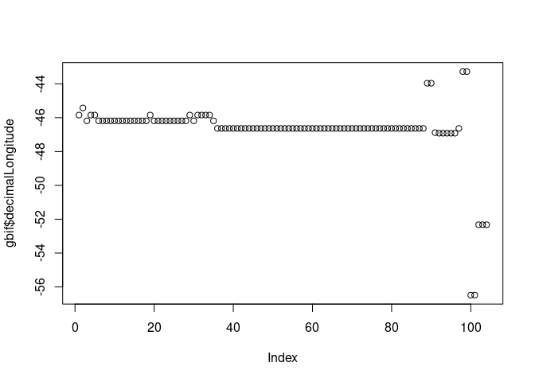

```r
#checking again
plot(gbif$decimalLongitude)
```

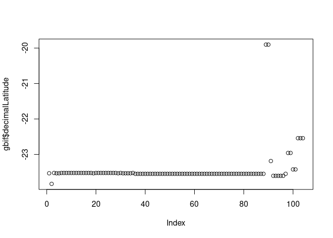

```r
plot(gbif$decimalLatitude)
```

*Plots de latitude e longitude.*

Note que plotamos latitude ou longitude em Y e seus registros ou linhas da tabela em X. Logo cada ponto em x corresponde à uma linha e cada valor correspondente em y uma latitude ou longitude. Note como os dados se repetem. É necessário remover as duplicatas.

### Removendo duplicatas

Remover duplicatas no R é fácil. Basta usar a função nativa “unique”. Essa função retarna apenas valores únicos. Lembre-se de executar essa função em um objeto novo para não sobrescrever nada.

```r
gbif.unique <- unique(gbif)
gbif.unique
```

```
##                species decimalLongitude decimalLatitude
## 1   Euglossa annectans        -45.84640       -23.53220
## 2   Euglossa annectans        -45.42640       -23.83110
## 3   Euglossa annectans        -46.18830       -23.52280
## 36  Euglossa annectans        -46.63610       -23.54750
## 89  Euglossa annectans        -43.96420       -19.90174
## 91  Euglossa annectans        -46.88420       -23.18640
## 92  Euglossa annectans        -46.91920       -23.60390
## 98  Euglossa annectans        -43.27721       -22.95831
## 100 Euglossa annectans        -56.48747       -23.42306
## 103 Euglossa annectans        -52.32778       -22.54250
```

Plotando no mapa novamente

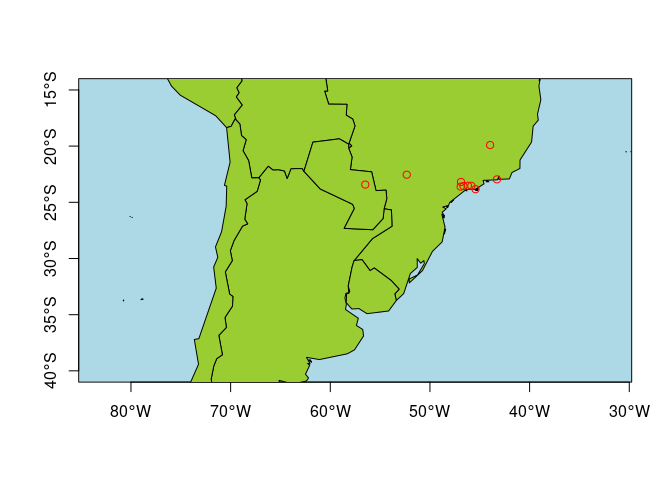

```r
plot(wrld_simpl, xlim=c(-60, -55), ylim=c(-40,-15), axes=T, col='olivedrab3',bg='lightblue')
points(gbif.unique[ ,c(2,3)], col="#FF0000")#lembre-se, pontos devem ser long e lat, nessa ordem. Ou seja, as colunas em gbif.unique devem ser "species", "decimalLong", "decimalLat".
```

#Salvando os dados trabalhados

Uma vez que os dados foram corrigidos, podemos salvá-los como entrada para os algoritmos de modelagem.

```r
#Creating an input for modelling
input <- gbif.unique

#saving the input table
write.table(input, "input.coordinates.txt", quote=F, row.names=F, sep = "\t")
```

#Verificando se os dados foram salvos:

Vamos agora importar os dados para checar se foram salvos corretamente:

```r
input.test <- read.csv("input.coordinates.txt", header = T, sep = "\t")
head(input.test)
```

```
##              species decimalLongitude decimalLatitude
## 1 Euglossa annectans         -45.8464       -23.53220
## 2 Euglossa annectans         -45.4264       -23.83110
## 3 Euglossa annectans         -46.1883       -23.52280
## 4 Euglossa annectans         -46.6361       -23.54750
## 5 Euglossa annectans         -43.9642       -19.90174
## 6 Euglossa annectans         -46.8842       -23.18640
```

```r
nrow(input.test)
```

```
## [1] 10
```

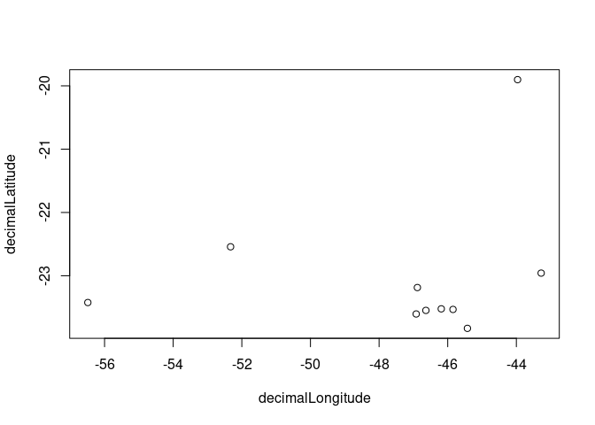

```r
plot(input.test[,2:3])
```

[Se tudo correu bem, o gráfico deve ser como o da figura, mostrando como as ocorrências se distribuem em lat e long]

Como ultima checagem, podemos olhar as ocorrências importadas em um mapa:

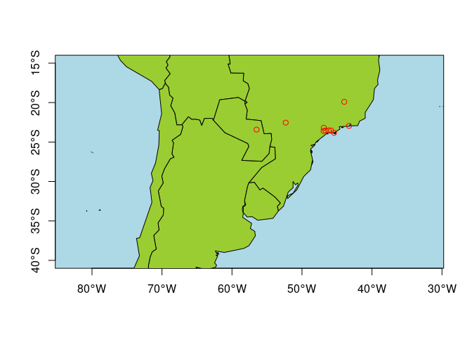

```r
plot(wrld_simpl, xlim=c(-60, -55), ylim=c(-40,-15), axes=T, col='olivedrab3',bg='lightblue')
points(input.test[ ,c(2,3)], col="#FF0000")#lembre-se, pontos devem ser long e lat, nessa ordem. Ou seja, as colunas em gbif.unique devem ser "species", "decimalLong", "decimalLat".
```

*Pontos plotados sobre o mapa cobrindo a porção sul da Mata Altântica.*

Espero que tenha aproveitado o tutorial. Vimos um pouco sobre como os erros dos bancos de dados podem “sujar” nossas análises, e que esses podem estar incompletos. Em breve veremos como aglutinar dados de diferentes bancos de dados para as análises.

Bons estudos!

[*Prof. Dr. Wilson Frantine-Silva*](https://www.researchgate.net/profile/Wilson-Frantine-Silva)  
*Pesquisador PNPD* - [ORCID](https://orcid.org/0000-0002-4293-0471)  
Universidade Estadual do Norte Fluminense Darcy Ribeiro - LCA.  
[Programa de Pós-Graduação em Ecologia e Recursos Naturais](https://uenf.br/posgraduacao/ecologia-recursosnaturais/)